# My SpotifyR report

Author

Zsuzsa Demeter

# Let’s Talk About Frank Ocean

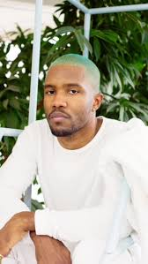

## Who is he?

**Frank Ocean** (born **Christopher Edwin Breaux**; October 28, 1987) is an American singer and songwriter. He has been credited as a pioneer of the alternative R&B genre. He has won two Grammy Awards among other accolades, and both of his studio albums have been listed on Rolling Stone’s 500 Greatest Albums of All Time list.

He is unfortunately not active in music anymore, having said that he wants to become a writer instead. After his second album, he released some singles here and there, worked as a photographer for magazines and launched a fashion brand called Homer

## His Albums

- channel ORANGE (2012) - nominated for Album of the Year and won Best Urban Contemporary Album at the Grammies
- Blonde (2016) - ranked first on Pitchfork’s Best Albums of the 2010s list
- Some singles, but nothing since 2020

## My Picks

### My Favorite Album

[figure not shown]

### My Favorite Song

[Godspeed (2016, Youtube link](https://www.youtube.com/watch?v=07XwUtF2lPQ)

[video not shown]

### My Favorite Lyrics

> *I’m sure we’re taller in another dimension*

> *You say we’re small and not worth the mention*

> *You’re tired of movin’, your body’s achin’*

> *We could vacay, there’s places to go*

> *Clearly, this isn’t all that there is*

> *Can’t take what’s been given (No way)*

> *But we’re so okay here, we’re doing fine*

> *Primal and naked*

> *You dream of walls that hold us in prison*

> *It’s just a skull, least that’s what they call it*

> *And we’re free to roam*

> (Outro of White Ferrari)

# Data Analysis

## Importing Data

```r
#These are the packages I will need for the analysis
library(dplyr)
library(ggplot2)

#Importing data into the data frame
df<-read.csv("C:/Users/ASUS/Desktop/LUC Data Science/singers_2023/singers_2023/Frank Ocean.csv")
```

## Take a glance at the data frame

```r
# Slice 5 random records in the dataframe
df |> dplyr::slice_sample(n=5) |> knitr::kable(digits = 2)
```

| artist_name | track_name | track_number | album_name | album_release_year | energy | valence | danceability | loudness | speechiness | liveness | tempo | key_mode | duration_ms |
| --- | --- | --- | --- | --- | --- | --- | --- | --- | --- | --- | --- | --- | --- |
| Frank Ocean | Monks | 13 | channel ORANGE | 2012 | 0.76 | 0.60 | 0.75 | -4.74 | 0.18 | 0.21 | 102.02 | C minor | 200240 |
| Frank Ocean | Pretty Sweet | 11 | Blonde | 2016 | 0.72 | 0.16 | 0.20 | -6.74 | 0.05 | 0.30 | 154.04 | C major | 158478 |
| Frank Ocean | Pink Matter | 15 | channel ORANGE | 2012 | 0.23 | 0.49 | 0.39 | -11.01 | 0.06 | 0.11 | 176.57 | B minor | 268813 |
| Frank Ocean | White Ferrari | 14 | Blonde | 2016 | 0.10 | 0.20 | 0.50 | -15.61 | 0.04 | 0.30 | 108.74 | C major | 248807 |
| Frank Ocean | Sweet Life | 5 | channel ORANGE | 2012 | 0.56 | 0.80 | 0.48 | -6.07 | 0.18 | 0.08 | 83.47 | B major | 262680 |

## Album Analysis (Valence and Energy)

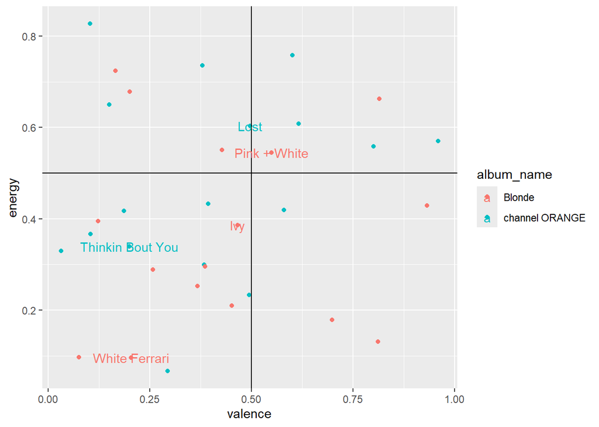

```r
subgroup <- df |> filter(track_name %in% c('Thinkin Bout You', 'Pink + White', 'White Ferrari', 'Lost', 'Ivy'))
ggplot(df, aes(x = valence, y = energy, color = album_name))+
  geom_point() +
  geom_hline(yintercept = 0.5) +
  geom_vline(xintercept = 0.5) +
  geom_text(data=subgroup, aes(label=track_name))
```

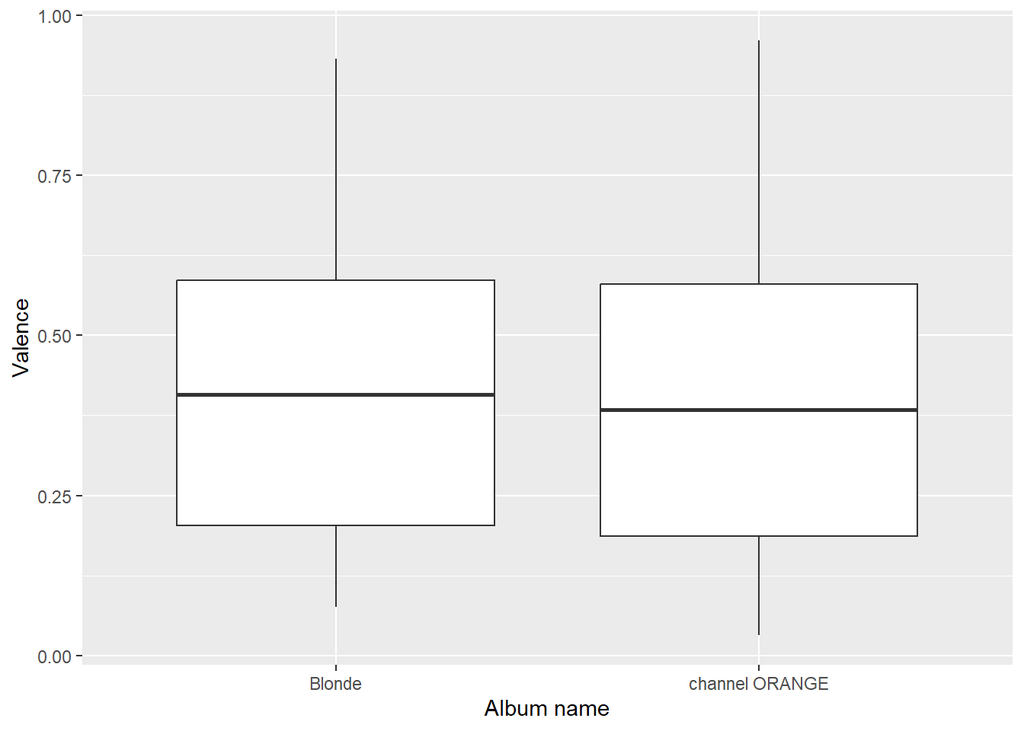

```r
# Change album_name from character to factor before plotting
df$album_name <- as.factor(df$album_name)
# Plot a boxplot
ggplot(df, aes(x=album_name, y=valence))+
  geom_boxplot()+
  labs(x="Album name", y="Valence")
```

The median valence is quite similar for both albums. Is there a difference in energy?

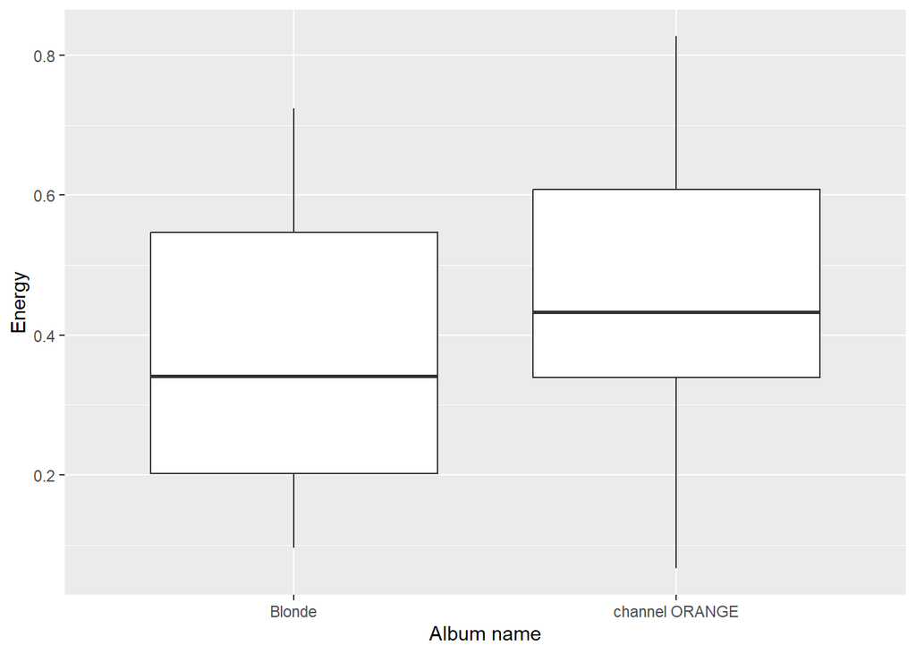

```r
ggplot(df, aes(x=album_name, y=energy))+
  geom_boxplot()+
  labs(x="Album name", y="Energy")
```

Turns out that Frank Ocean’s first album was more energetic than the second!

## Album Analysis 2 (Speechiness)

Maybe there is a difference in speechiness?

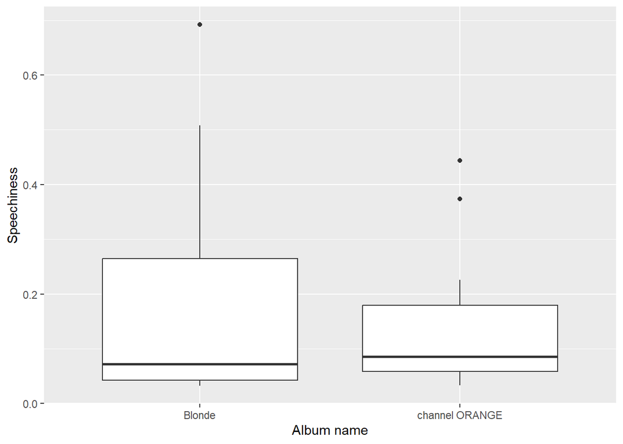

```r
ggplot(df, aes(x=album_name, y=speechiness))+
  geom_boxplot()+
  labs(x="Album name", y="Speechiness")
```

In general, his songs seem to be more instrumental-focused. But what are the 3 outliers?

## Frank Ocean’s 3 most lyric-focused songs

```r
df |> slice_max(speechiness, n=3) |> dplyr::select(track_name, album_name, album_release_year, speechiness) |> knitr::kable(digits = 2)
```

| track_name | album_name | album_release_year | speechiness |
| --- | --- | --- | --- |
| Facebook Story | Blonde | 2016 | 0.69 |
| Futura Free | Blonde | 2016 | 0.51 |
| Be Yourself | Blonde | 2016 | 0.49 |

2 of these three songs are actually interludes of someone talking, which explains the speechiness:)

## Frank Ocean’s Happiest Song

```r
df |> slice_max(valence, n=3) |> dplyr::select(track_name, album_name, album_release_year, valence) |> knitr::kable(digits = 2)
```

| track_name | album_name | album_release_year | valence |
| --- | --- | --- | --- |
| Fertilizer | channel ORANGE | 2012 | 0.96 |
| Be Yourself | Blonde | 2016 | 0.93 |
| Close To You | Blonde | 2016 | 0.81 |

Fertilizer is actually a 39-second song with only 4 lines. Wanna listen to it?

[video not shown]